# Predictive Model for Breast Cancer Incidence

Bharat Solanky and Aadya Chawla

[Link to GitHub page](https://bharatsolanky.github.io/)

## Project Background:

More than 200,000 women are diagnosed with breast cancer every year. It is the most common form of cancer for women and is responsible for the second highest number of deaths for females in the United States. We want to know how can we better understand the properties of tumor cells and how age and tumor size affects the likelihood of being diagnosed with breast cancer. This is important because a study by Orlando Health showed that 22% of women age 35 to 44 have never had a mammogram and “have no plans to get one”. Our work can hopefully give us a better understanding of specifically how catastrophic this issue is and potentially provide a reason to spread more awareness on the subject.

## Project Goals:

The goals of this project were to produce a predictive model to determine likelihood of breast cancer incidence in female patients using physical metrics, such as concavity, radius, and texture of perceived benign tumors. Moreover, we then wanted to understand how certain hormonal protein levels can further be used to give an indication on what type of surgery is required for women who have malignant tumors.

## Project DataSet and Plan:

1. Concave_points_worst: The average value for cancer is 0.18, whereas it is 0.07 for benign;
2. Radius_worst: The average value for cancer is 21.13, whereas it is 13.38 for benign; and
3. Texture_worst: The average value for cancer is 29.32 whereas it is 23.52 for benign;

Our goal was to also provide guidelines for medical professionals to assist them with the process of visual diagnosis (prediction) by identifying potentially extreme values above/below which the likelihood of breast cancer changes significantly. For example, for what value of Radius_worst does the possibility of cancer have a likelihood of 95% or 100%.

## Collaboration :

We created a google colab drive to share files and so that we could easily edit and write code live. We met weekly leading up to the final deadline to divide the work and enhance our project objectives. Throughout the semester, we used text messages and met in person to communicate with each other.

## ETL (Extraction, Transform, and Load):

The first download does not have any missing data for any of the features. It does however have "unnamed data", which was promptly removed after loading it below.

### Filtering, Sorting, and Plotting Data Points

```python
from google.colab import drive
drive.mount('/content/drive')
```

```python
#mounting google collab to google drive
from google.colab import drive
drive.mount('/content/drive')
```

```python
! pwd

#directory contains csv file
%cd /content/drive/My Drive/DataScienceProject
!git pull


import pandas as pd
from matplotlib import pyplot as plt
from itertools import cycle, islice
pd.options.display.max_rows = 8

df = pd.read_csv("data.csv")
#This reads the data file which is named data.csv

#Deletes unused column
del df['Unnamed: 32']

#Displays head for first dataset
df.head()
```

```
/content/drive/My Drive/DataScienceProject
/content/drive/My Drive/DataScienceProject
fatal: not a git repository (or any parent up to mount point /content)
Stopping at filesystem boundary (GIT_DISCOVERY_ACROSS_FILESYSTEM not set).
```

|  | id | diagnosis | radius_mean | texture_mean | perimeter_mean | area_mean | smoothness_mean | compactness_mean | concavity_mean | concave points_mean | ... | radius_worst | texture_worst | perimeter_worst | area_worst | smoothness_worst | compactness_worst | concavity_worst | concave points_worst | symmetry_worst | fractal_dimension_worst |
| --- | --- | --- | --- | --- | --- | --- | --- | --- | --- | --- | --- | --- | --- | --- | --- | --- | --- | --- | --- | --- | --- |
| 0 | 842302 | M | 17.99 | 10.38 | 122.80 | 1001.0 | 0.11840 | 0.27760 | 0.3001 | 0.14710 | ... | 25.38 | 17.33 | 184.60 | 2019.0 | 0.1622 | 0.6656 | 0.7119 | 0.2654 | 0.4601 | 0.11890 |
| 1 | 842517 | M | 20.57 | 17.77 | 132.90 | 1326.0 | 0.08474 | 0.07864 | 0.0869 | 0.07017 | ... | 24.99 | 23.41 | 158.80 | 1956.0 | 0.1238 | 0.1866 | 0.2416 | 0.1860 | 0.2750 | 0.08902 |
| 2 | 84300903 | M | 19.69 | 21.25 | 130.00 | 1203.0 | 0.10960 | 0.15990 | 0.1974 | 0.12790 | ... | 23.57 | 25.53 | 152.50 | 1709.0 | 0.1444 | 0.4245 | 0.4504 | 0.2430 | 0.3613 | 0.08758 |
| 3 | 84348301 | M | 11.42 | 20.38 | 77.58 | 386.1 | 0.14250 | 0.28390 | 0.2414 | 0.10520 | ... | 14.91 | 26.50 | 98.87 | 567.7 | 0.2098 | 0.8663 | 0.6869 | 0.2575 | 0.6638 | 0.17300 |
| 4 | 84358402 | M | 20.29 | 14.34 | 135.10 | 1297.0 | 0.10030 | 0.13280 | 0.1980 | 0.10430 | ... | 22.54 | 16.67 | 152.20 | 1575.0 | 0.1374 | 0.2050 | 0.4000 | 0.1625 | 0.2364 | 0.07678 |

5 rows × 32 columns

Below are the dtypes for certain variables within the dataset. Later on, the diagnosis is modified to become a float64 from an object data type to make it a numerical value which will help with K-neighbor regression calculation.

```python
df.dtypes
```

```
id                           int64
diagnosis                   object
radius_mean                float64
texture_mean               float64
                            ...
concavity_worst            float64
concave points_worst       float64
symmetry_worst             float64
fractal_dimension_worst    float64
Length: 32, dtype: object
```

Below is shown the columns and head rows for the second data set. What was formerly "anaplastic; Grade IV" was cleaned up to match other grades in simply being a number (i.e. 4).

```python
df2 = pd.read_csv("Breast_Cancer.csv")
#This reads the second data file which is named Breast_Cancer.csv

def transform(x):
    x = x.replace(" anaplastic; Grade IV", "4")
    return str(x)
df2['Grade'] = df2['Grade'].apply(transform)
df2['Grade'].value_counts()
df2.head()
```

|  | Age | Race | Marital Status | T Stage | N Stage | 6th Stage | differentiate | Grade | A Stage | Tumor Size | Estrogen Status | Progesterone Status | Regional Node Examined | Reginol Node Positive | Survival Months | Status |
| --- | --- | --- | --- | --- | --- | --- | --- | --- | --- | --- | --- | --- | --- | --- | --- | --- |
| 0 | 68 | White | Married | T1 | N1 | IIA | Poorly differentiated | 3 | Regional | 4 | Positive | Positive | 24 | 1 | 60 | Alive |
| 1 | 50 | White | Married | T2 | N2 | IIIA | Moderately differentiated | 2 | Regional | 35 | Positive | Positive | 14 | 5 | 62 | Alive |
| 2 | 58 | White | Divorced | T3 | N3 | IIIC | Moderately differentiated | 2 | Regional | 63 | Positive | Positive | 14 | 7 | 75 | Alive |
| 3 | 58 | White | Married | T1 | N1 | IIA | Poorly differentiated | 3 | Regional | 18 | Positive | Positive | 2 | 1 | 84 | Alive |
| 4 | 47 | White | Married | T2 | N1 | IIB | Poorly differentiated | 3 | Regional | 41 | Positive | Positive | 3 | 1 | 50 | Alive |

## Exploratory Data Analysis (EDA)

Below is a bar chart showing the 4 stages of breast cancer with outcomes of patients plotted in both green and red. Green describes a patient being alive when this data set was taken and red represents a patient passing away during this time. As can be seen, if a patient's stage of breast cancer was higher prior to surgery, their likelihood of passing was also greater.

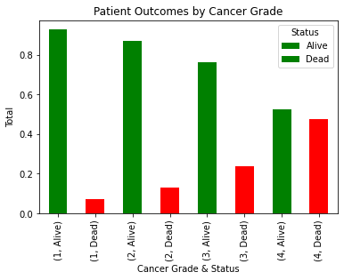

```python
my_colors = list(islice(cycle(['g', 'r']), None, len(df)))
df2.groupby('Grade')["Status"].value_counts(normalize=True)
df2.groupby('Grade')["Status"].value_counts(normalize=True).plot(kind='bar', legend = True, color=my_colors)
plt.legend(my_colors, loc='upper right', title='Status')
chart1 = df2.groupby('Grade')["Status"].value_counts(normalize=True).plot(kind='bar', legend = True, color=my_colors, title = 'Patient Outcomes by Cancer Grade')
plt.legend(['Alive', 'Dead'],
            loc='upper right', title='Status')


chart1.set_ylabel("Total")
chart1.set_xlabel("Cancer Grade & Status")
```

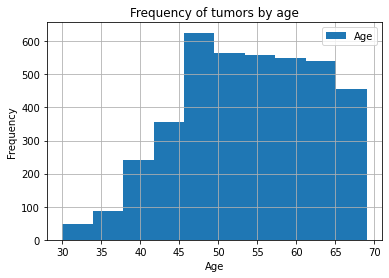

```python
chart2 = df2.hist(column='Age', legend = True)
plt.title('Frequency of tumors by age')
plt.xlabel('Age')
plt.ylabel('Frequency')
```

In the data frame displayed below, we can see a clear association between Tumor Size and grade of cancer...As the grade or "stage" of cancer increases, tumor size seems to match in also increasing. The chart doesn't clearly show this, as there are very few data points in the 4 category to make it visible, however the averages in the dataframe just above it make it clear.

```
             Age  Tumor Size  Regional Node Examined  Reginol Node Positive  \
Grade
1      55.289134   26.364641               12.675875               3.068140
2      54.322416   29.729051               14.387920               3.922586
3      52.615662   33.823582               15.111611               5.154815
4      52.315789   44.157895               14.473684               6.157895

       Survival Months       Size
Grade
1            72.937385  26.364641
2            72.179073  29.729051
3            68.749775  33.823582
4            64.421053  44.157895
```

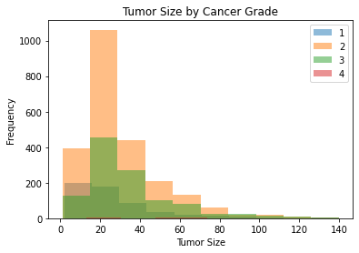

```python
#Copying Tumor Size to another column with shorter name for ease
df2["Size"] = df2["Tumor Size"]

chart3 = df2.groupby("Grade").Size.plot.hist(alpha=.5, density=False, legend=True)
plt.title('Tumor Size by Cancer Grade')
plt.xlabel('Tumor Size')
print(df2.groupby("Grade").mean())
```

```python
df3 = pd.read_csv("BRCA.csv")
#This reads the data file which is named BRCA.csv

df3.head()
#Third dataset --> contains data on surgery type and protein concentration, both of which are new data columns
```

|  | Patient_ID | Age | Gender | Protein1 | Protein2 | Protein3 | Protein4 | Tumour_Stage | Histology | ER status | PR status | HER2 status | Surgery_type | Date_of_Surgery | Date_of_Last_Visit | Patient_Status |
| --- | --- | --- | --- | --- | --- | --- | --- | --- | --- | --- | --- | --- | --- | --- | --- | --- |
| 0 | TCGA-D8-A1XD | 36.0 | FEMALE | 0.080353 | 0.42638 | 0.54715 | 0.273680 | III | Infiltrating Ductal Carcinoma | Positive | Positive | Negative | Modified Radical Mastectomy | 15-Jan-17 | 19-Jun-17 | Alive |
| 1 | TCGA-EW-A1OX | 43.0 | FEMALE | -0.420320 | 0.57807 | 0.61447 | -0.031505 | II | Mucinous Carcinoma | Positive | Positive | Negative | Lumpectomy | 26-Apr-17 | 09-Nov-18 | Dead |
| 2 | TCGA-A8-A079 | 69.0 | FEMALE | 0.213980 | 1.31140 | -0.32747 | -0.234260 | III | Infiltrating Ductal Carcinoma | Positive | Positive | Negative | Other | 08-Sep-17 | 09-Jun-18 | Alive |
| 3 | TCGA-D8-A1XR | 56.0 | FEMALE | 0.345090 | -0.21147 | -0.19304 | 0.124270 | II | Infiltrating Ductal Carcinoma | Positive | Positive | Negative | Modified Radical Mastectomy | 25-Jan-17 | 12-Jul-17 | Alive |
| 4 | TCGA-BH-A0BF | 56.0 | FEMALE | 0.221550 | 1.90680 | 0.52045 | -0.311990 | II | Infiltrating Ductal Carcinoma | Positive | Positive | Negative | Other | 06-May-17 | 27-Jun-19 | Dead |

```python
df3["Protein2"].value_counts()
#Drops null values
df3.dropna()
```

|  | Patient_ID | Age | Gender | Protein1 | Protein2 | Protein3 | Protein4 | Tumour_Stage | Histology | ER status | PR status | HER2 status | Surgery_type | Date_of_Surgery | Date_of_Last_Visit | Patient_Status |
| --- | --- | --- | --- | --- | --- | --- | --- | --- | --- | --- | --- | --- | --- | --- | --- | --- |
| 0 | TCGA-D8-A1XD | 36.0 | FEMALE | 0.080353 | 0.42638 | 0.54715 | 0.273680 | III | Infiltrating Ductal Carcinoma | Positive | Positive | Negative | Modified Radical Mastectomy | 15-Jan-17 | 19-Jun-17 | Alive |
| 1 | TCGA-EW-A1OX | 43.0 | FEMALE | -0.420320 | 0.57807 | 0.61447 | -0.031505 | II | Mucinous Carcinoma | Positive | Positive | Negative | Lumpectomy | 26-Apr-17 | 09-Nov-18 | Dead |
| 2 | TCGA-A8-A079 | 69.0 | FEMALE | 0.213980 | 1.31140 | -0.32747 | -0.234260 | III | Infiltrating Ductal Carcinoma | Positive | Positive | Negative | Other | 08-Sep-17 | 09-Jun-18 | Alive |
| 3 | TCGA-D8-A1XR | 56.0 | FEMALE | 0.345090 | -0.21147 | -0.19304 | 0.124270 | II | Infiltrating Ductal Carcinoma | Positive | Positive | Negative | Modified Radical Mastectomy | 25-Jan-17 | 12-Jul-17 | Alive |
| ... | ... | ... | ... | ... | ... | ... | ... | ... | ... | ... | ... | ... | ... | ... | ... | ... |
| 330 | TCGA-A8-A085 | 44.0 | MALE | 0.732720 | 1.11170 | -0.26952 | -0.354920 | II | Infiltrating Lobular Carcinoma | Positive | Positive | Negative | Other | 01-Nov-19 | 04-Mar-20 | Dead |
| 331 | TCGA-A1-A0SG | 61.0 | FEMALE | -0.719470 | 2.54850 | -0.15024 | 0.339680 | II | Infiltrating Ductal Carcinoma | Positive | Positive | Negative | Lumpectomy | 11-Nov-19 | 18-Jan-21 | Dead |
| 332 | TCGA-A2-A0EU | 79.0 | FEMALE | 0.479400 | 2.05590 | -0.53136 | -0.188480 | I | Infiltrating Ductal Carcinoma | Positive | Positive | Positive | Lumpectomy | 21-Nov-19 | 19-Feb-21 | Dead |
| 333 | TCGA-B6-A40B | 76.0 | FEMALE | -0.244270 | 0.92556 | -0.41823 | -0.067848 | I | Infiltrating Ductal Carcinoma | Positive | Positive | Negative | Lumpectomy | 11-Nov-19 | 05-Jan-21 | Dead |

317 rows × 16 columns

Below are two grouped dataframes which are filtered to displayed the status (i.e. dead or alive) of patients at the time of taking the data based on their tumor stage during surgery. Clearly, as tumor stage increased, their chance of survival post surgery decreased.

```python
df3.groupby('Tumour_Stage')["Patient_Status"].value_counts()
```

```
Tumour_Stage  Patient_Status
I             Alive              51
              Dead               10
II            Alive             144
              Dead               38
III           Alive              60
              Dead               18
Name: Patient_Status, dtype: int64
```

```python
df3.groupby('Tumour_Stage')["Patient_Status"].value_counts(normalize=True)
```

```
Tumour_Stage  Patient_Status
I             Alive             0.836066
              Dead              0.163934
II            Alive             0.791209
              Dead              0.208791
III           Alive             0.769231
              Dead              0.230769
Name: Patient_Status, dtype: float64
```

This plotted bar chart further shows that as the stage of cancer got worse, a more invasive, more costly surgery was required. For context, a simple masectomy (plotted in yellow) requires removal of significant tissue from a patient's breast and modified radical mastecomy (plotted in red) requires complete removal of breast and skin that surrounds it.

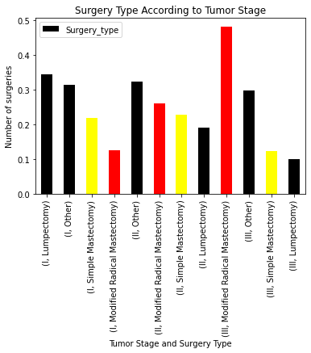

```python
tumor_c = list(islice(cycle(['b', 'y', 'r', 'g']), None, len(df)))
chart4 = df3.groupby('Tumour_Stage')["Surgery_type"].value_counts(normalize=True).plot(kind='bar', legend=True,
                                                                                       color = ['black', 'black', 'yellow', 'red',
                                                                                                'black', 'red', 'yellow','black',
                                                                                                'red','black','yellow','black'],
                                                                                       title = 'Surgery Type According to Tumor Stage')
chart4.set_xlabel("Tumor Stage and Surgery Type")
chart4.set_ylabel("Number of surgeries")
```

Below, it was attempted to see if the means of protein concentration values of patients had any relation to tumor stage. Although protein 2 and protein 4 concentrations both show consistently declining values with increasing tumor stage, it is unclear if this association has any indication of tumor stage prediction.

```python
df3.mean()
df3.groupby(by=["Tumour_Stage"]).mean()
```

| Tumour_Stage | Age | Protein1 | Protein2 | Protein3 | Protein4 |
| --- | --- | --- | --- | --- | --- |
| I | 62.359375 | -0.014430 | 1.001318 | -0.165147 | 0.037828 |
| II | 59.052910 | -0.007734 | 0.964763 | -0.065409 | 0.018023 |
| III | 55.753086 | -0.094220 | 0.862207 | -0.088845 | -0.031453 |

From the first dataframe df (again shown below), we established a relationship between "radius_worst" (a variable describing the radius of the largest tumor present in a breast cancer patient) and "radius_mean" (mean radius of that patient) and its "radius_se" (standard error of the sizes of the radius from a patient) to understand how many standard errors away from the mean that *nearly all* of the diagnoses are *malignant*. This is a step we can use to help guide our question searching process. Below, it can be seen that as the multiplier value (5 to 7 to 9 to 11) increases, the percentage of diagnoses being malignant increases. This may show that within a patient's tumors, if one is significantly larger than the mean, then it is likely that that specific tumor is malignant.

```python
df.head()
```

|  | id | diagnosis | radius_mean | texture_mean | perimeter_mean | area_mean | smoothness_mean | compactness_mean | concavity_mean | concave points_mean | ... | radius_worst | texture_worst | perimeter_worst | area_worst | smoothness_worst | compactness_worst | concavity_worst | concave points_worst | symmetry_worst | fractal_dimension_worst |
| --- | --- | --- | --- | --- | --- | --- | --- | --- | --- | --- | --- | --- | --- | --- | --- | --- | --- | --- | --- | --- | --- |
| 0 | 842302 | M | 17.99 | 10.38 | 122.80 | 1001.0 | 0.11840 | 0.27760 | 0.3001 | 0.14710 | ... | 25.38 | 17.33 | 184.60 | 2019.0 | 0.1622 | 0.6656 | 0.7119 | 0.2654 | 0.4601 | 0.11890 |
| 1 | 842517 | M | 20.57 | 17.77 | 132.90 | 1326.0 | 0.08474 | 0.07864 | 0.0869 | 0.07017 | ... | 24.99 | 23.41 | 158.80 | 1956.0 | 0.1238 | 0.1866 | 0.2416 | 0.1860 | 0.2750 | 0.08902 |
| 2 | 84300903 | M | 19.69 | 21.25 | 130.00 | 1203.0 | 0.10960 | 0.15990 | 0.1974 | 0.12790 | ... | 23.57 | 25.53 | 152.50 | 1709.0 | 0.1444 | 0.4245 | 0.4504 | 0.2430 | 0.3613 | 0.08758 |
| 3 | 84348301 | M | 11.42 | 20.38 | 77.58 | 386.1 | 0.14250 | 0.28390 | 0.2414 | 0.10520 | ... | 14.91 | 26.50 | 98.87 | 567.7 | 0.2098 | 0.8663 | 0.6869 | 0.2575 | 0.6638 | 0.17300 |
| 4 | 84358402 | M | 20.29 | 14.34 | 135.10 | 1297.0 | 0.10030 | 0.13280 | 0.1980 | 0.10430 | ... | 22.54 | 16.67 | 152.20 | 1575.0 | 0.1374 | 0.2050 | 0.4000 | 0.1625 | 0.2364 | 0.07678 |

5 rows × 32 columns

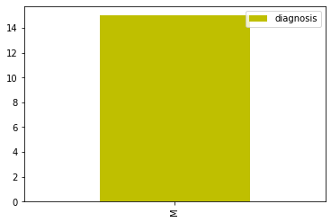

```python
my_colors = list(islice(cycle(['y', 'g']), None, len(df)))


rd = df[df["radius_worst"] > (df["radius_mean"] + 11 * df["radius_se"])]
rd["diagnosis"].value_counts()
rd["diagnosis"].value_counts().plot(kind='bar', legend = True, color=my_colors)
```

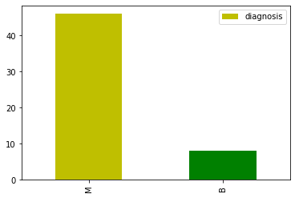

```python
rd2 = df[df["radius_worst"] > (df["radius_mean"] + 9 * df["radius_se"])]
rd2["diagnosis"].value_counts()
rd2["diagnosis"].value_counts().plot(kind='bar', legend = True, color=my_colors)
```

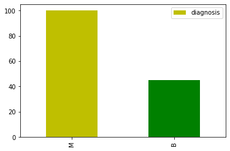

```python
rd3 = df[df["radius_worst"] > (df["radius_mean"] + 7 * df["radius_se"])]
rd3["diagnosis"].value_counts()
rd3["diagnosis"].value_counts().plot(kind='bar', legend = True, color=my_colors)
```

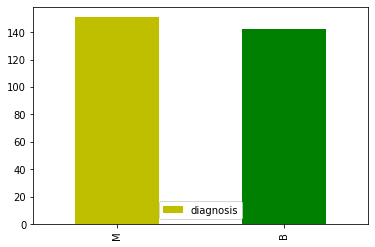

```python
rd4 = df[df["radius_worst"] > (df["radius_mean"] + 5 * df["radius_se"])]
rd4["diagnosis"].value_counts()
rd4["diagnosis"].value_counts().plot(kind='bar', legend = True, color=my_colors)
```

**K-Nearest Neighbors Method**

```python
import numpy as np
import matplotlib.pyplot as plt

train = df.sample(frac=.5)
val = df.drop(train.index)

# Features used for prediction
features = ["radius_mean",	"texture_mean",	"perimeter_mean",	"area_mean",	"smoothness_mean",	"compactness_mean",	"concavity_mean"]

X_train_dict = train[features].to_dict(orient="records")
X_val_dict = val[features].to_dict(orient="records")

y_train = train["diagnosis"]
y_val = val["diagnosis"]

from sklearn.feature_extraction import DictVectorizer
from sklearn.preprocessing import StandardScaler
from sklearn.neighbors import KNeighborsRegressor
from sklearn.model_selection import cross_val_score
from sklearn.neighbors import KNeighborsClassifier
from sklearn.model_selection import train_test_split

def get_val_error(X_train_dict, y_train, X_val_dict, y_val):

    # convert categorical variables to dummy variables
    vec = DictVectorizer(sparse=False)
    vec.fit(X_train_dict)
    X_train = vec.transform(X_train_dict)
    X_val = vec.transform(X_val_dict)

    # standardize the data
    scaler = StandardScaler()
    scaler.fit(X_train)
    X_train_sc = scaler.transform(X_train)
    X_val_sc = scaler.transform(X_val)

    # Fit a 10-nearest neighbors model.
    model = KNeighborsClassifier(n_neighbors=7)
    model.fit(X_train_sc, y_train)

    # Make predictions on the validation set.
    y_pred = model.predict(X_val_sc)

    return model.score(X_val_sc,y_val)
```

```python
val1 = get_val_error(X_train_dict, y_train, X_val_dict, y_val)
val2 = get_val_error(X_val_dict, y_val, X_train_dict, y_train)

print("Test Score:",val1)
print("Test Score:",val2)

(val1+val2)/2
```

```
Test Score: 0.9157894736842105
Test Score: 0.9295774647887324
```

```
0.9226834692364714
```

As can be seen above, our knn classifier appears to be an excellent predictor. It accurately predicts 93% of diagnoses based off the 7 independent variables, those being radius, texture, perimeter, area, smoothness, compactness, and concavity. With such a high value, it's clear that breast cancer detection is possible with great accuracy. Moreover, with the Canadian Medical Association Journal citing that the combined ultrasound and mammography detection rate was 37.5%, it appears that taking simple measurements of breast tumor metrics (via a MRI scan) can reveal what appears to be a higher detection possibility.

Below the correlation between mean radius and diagnosis is found to be .730, incidicating a strong positive relationship between the two. This affirms above findings on diagnosis.

```python
def transform(x):
    x = x.replace("B", "0").replace("M", "1")
    return float(x)
df['diagnosis'] = df['diagnosis'].apply(transform)


x = df["radius_mean"]
y = df['diagnosis']
a = df["area_mean"]
r = np.corrcoef(x, y)
r
```

```
array([[1.        , 0.73002851],
       [0.73002851, 1.        ]])
```

**Project Overview**

We created 2 major predictors to find out how age, tumor size, and other common tumor variables can impact tumor diagnosis and determine likelihood of extensive surgery types.

1. Firstly, by using mean radius and standard error of the radius of a person's tumor, we predicted whether the largest tumor is malignant or benign. (mean radius and standard error are independent variables and the simple equation (as shown above) predicted likelihood of malignant tumors increases as the radius of the largest tumor significantly exceeds the mean)
2. Secondly, using k nearest neighbor classifier, we found out the relationship between chosen training variables, including mean radius, texture, perimeter, smoothness, etc., and the predictor value or diagnosis. Our model accrutaely predicted diagnosis with a low error value.

## Project Conclusion:

Tumor size shows strong correlation to a malignant diagnosis Moreover, malignant tumors generally progress steadily to higher stages of cancer, which if not detected on time, require more extensive, costly surgeries and have significantly lower survival rates.

```python
%%shell
#pwd
jupyter nbconvert --to html ///content/drive/MyDrive/DataScienceProject/FinalMilestone.ipynb
```

```
[NbConvertApp] Converting notebook ///content/drive/MyDrive/DataScienceProject/FinalMilestone.ipynb to html
[NbConvertApp] Writing 461956 bytes to ///content/drive/MyDrive/DataScienceProject/FinalMilestone.html
```